# 9 Distribution d’échantillonnage

- quelle est la probabilité, en tirant un échantillon de 100 observations, que la proportion des individus possédant un ordinateur soit supérieure à 0.75? La Figure 10.13 illustre cette situation.

```r
pr <- mean(distprop > 0.75)
```

$$P(p>0.75)=0.206$$

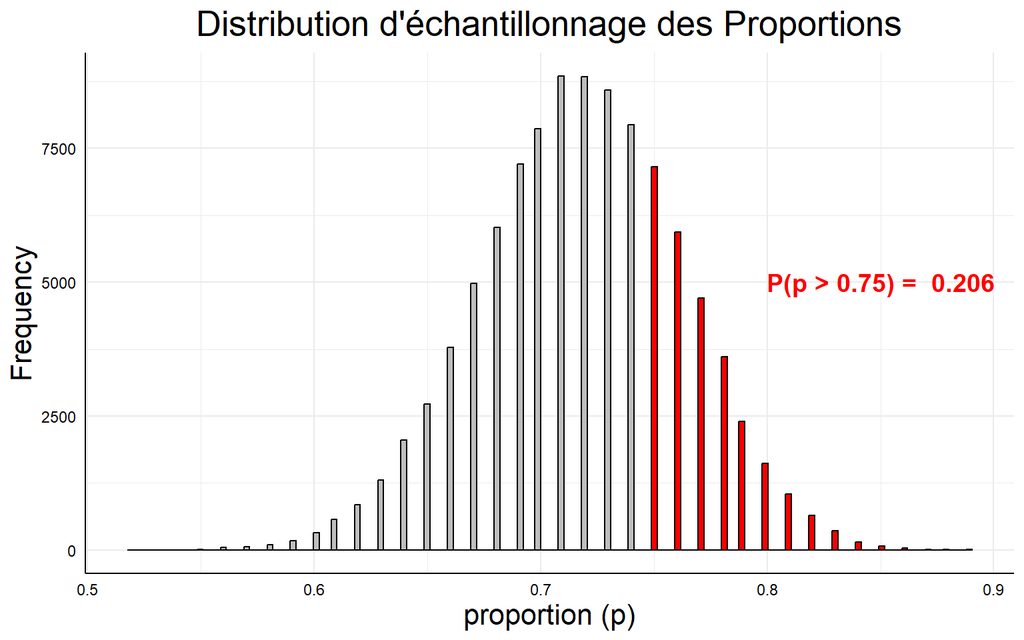

Figure 9.22: Distribution d’échantillonnage des proportions

- Quelle est la probabilité, en tirant un échantillon de 100 observations, d’obtenir une proportion échantillonnale comprise entre 0.6 et 0.75? La Figure 10.14 illustre cette situation.

```r
pr <- mean((distprop < 0.75) & (distprop > 0.6))
cat("P(0.6 < x < 0.75) = ", pr)
```

```
#> P(0.6 < x < 0.75) =  0.71532
```

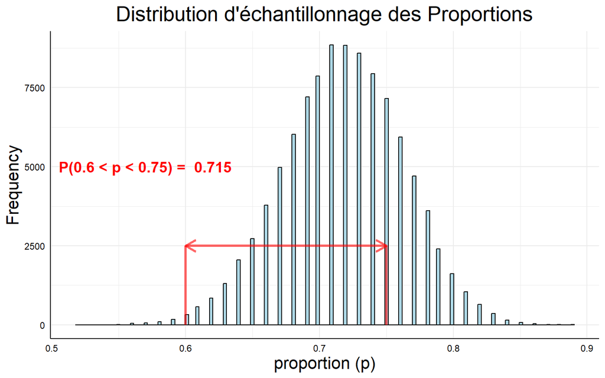

Figure 9.23: Distribution d’échantillonnage des proportions

- À l’intérieur de quelles limites retrouve-t-on les 95% centraux des proportions obtenues pour des échantillons de 100 observations, tel qu’illustré dans la Figure 10.15?

```r
lim <- quantile(distprop,c(0.025, 0.975))
cat("P(",lim[1]," < x < ", lim[2],") = 95%")
```

```
#> P( 0.63  < x <  0.8 ) = 95%
```

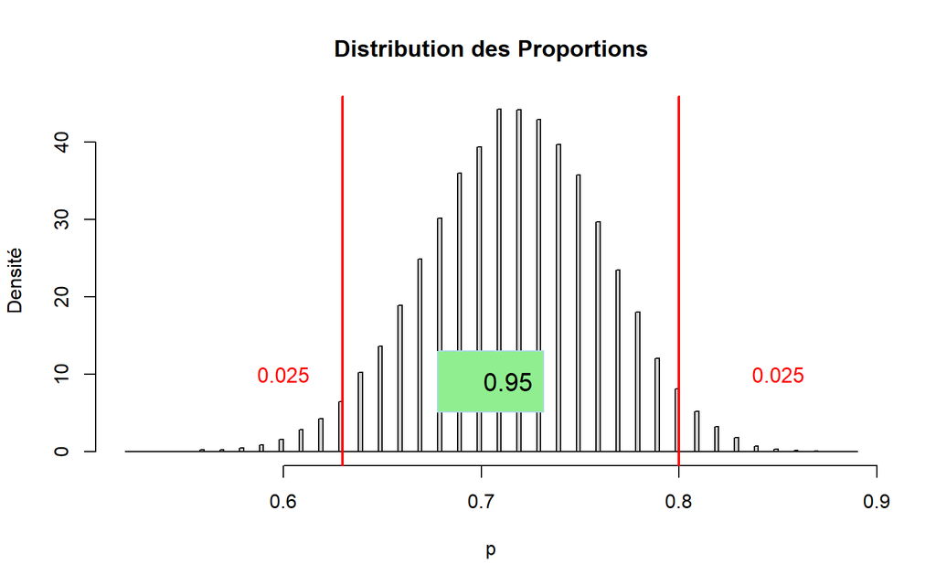

Figure 9.24: Distribution d’échantillonnage des proportions

Dans certains cas, la probabilité associée à un ‘succès’ est très faible, ou très élevée. Lorsque la distribution binomiale a été discutée au chapitre 2, démonstration a été faite que dans de tels cas, la distribution de probabilité devient asymétrique. Cette caractéristique aura un impact sur la distribution d’échantillonnage des proportions. Pour s’en convaincre, formons une population de 200,000 observations binaires, la probabilité d’un ‘succès’ étant égale à 0.95:

```r
pr <- 0.95
x <- sample(0:1, 200000, replace=TRUE, prob=c(1-pr, pr))
```

De cette population, tirons un grand nombre d’échantillons de taille 100, et pour chacun de ces échantillons obtenons la proportion des ‘succès’. La Figure 9.25 illustre la distribution résultant de cette opération.

```r
nrep <- 100000
distprop <- replicate(nrep, mean(sample(x, 100, replace=FALSE)))
mup <- mean(distprop)
sep <- sd(distprop)
```

$$\mu_p= 0.95 \qquad \sigma_p= 0.022$$

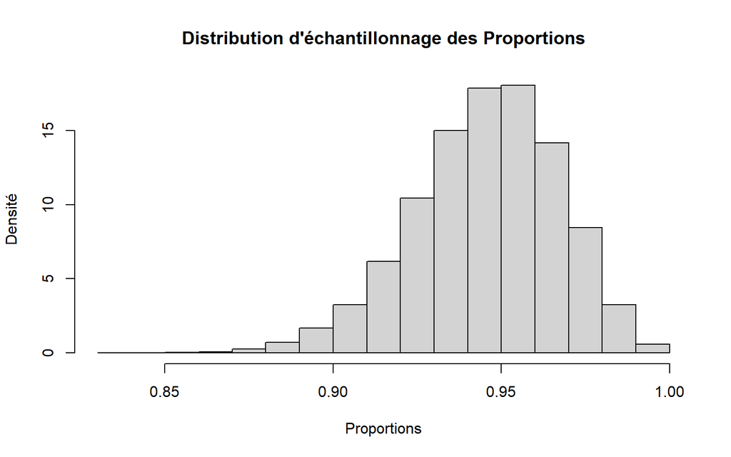

Figure 9.25: Distribution d’échantillonnage des proportions pour une probabilité de succès élevée (p=0.95)

Il ne faut pas se surprendre le l’asymétrie de cette distribution. En effet, une proportion est bornée par les limites 0 et 1. Plus la proportion au niveau de la population est rapprochée de l’une ou l’autre de ces valeurs, plus la symétrie est difficile à obtenir. L’impact de l’asymétrie de la distribution d’échantillonnage se fera sentir lorsqu’une approche analytique sera utilisée pour ce type de travail.

### 9.5.2 Approche analytique

Dans la section précédente, on a pu constater intuitivement que sous réserve de certains postulats, la distribution d’échantillonnage des proportions prenait une forme gaussienne, avec une moyenne égale, à la limite, à la proportion de ‘succès’ au niveau de la population ($\mu_p=\pi$). La dispersion de cette distribution d’échantillonnage est quantifiée par son erreur-standard, $\sigma_p$, qu’il nous reste à déterminer.

Pour une population infinie, l’erreur-standard des proportions se définit par l’équation Équation 9.10.

$$\sigma_p=\sqrt{\frac{p(1-p)}{n}} \tag{9.10}$$

Pour une population finie, comme ce fut le cas pour l’erreur-standard des moyennes, le coefficient d’exhaustivité est introduit dans l’équation Équation 9.11.

$$\sigma_p=\sqrt{\frac{p(1-p)}{n}}\sqrt{1-\frac{n}{N}} \tag{9.11}$$

Il faut mentionner que la ‘normalité’ de la distribution d’échantillonnage des proportions suppose que la taille de l’échantillon soit suffisamment grande, et que la probabilité d’un ‘succès’ ne soit pas trop extrême. On considère un échantillon comme étant de taille suffisante si la relation Équation 9.12) est vérifiée:

$$\left [ p-3\sigma_p,~~p+3\sigma_p \right ]\subset \left [0,~~1 \right ] \tag{9.12}$$

En bref, un échantillon est de taille suffisante si les valeurs de $p\pm 3 \sigma_p$ se trouvent comprises entre 0 et 1.

À titre d’exemple, retournons à la population (infinie) d’étudiants aux Études supérieures, et supposons que l’on ait connaissance que la proportion de ces étudiants qui possèdent un ordinateur personnel est égale à 0.72, ou 72%. En tirant des échantillons de 100 étudiants, et en calculant la proportion de propriétaires d’ordinateurs, quelle est la probabilité que cette dernière soit supérieure à 0.75 ?

- dans ces conditions, on peut obtenir l’erreur-standard des proportions en calculant:

$$\sigma_p=\sqrt{\frac{p(1-p)}{n}} =\sqrt{\frac{0.72(1-0.72)}{100}}=0.0449$$
Sous R, on obtient effectivement:

```r
sep <- sqrt(0.72*(1-0.72)/100)
```

$$\sigma_p=0.045$$
Est-ce qu’une taille *n*=100 est suffisante pour étudier la présente distribution? Ce sera le cas si:

$$\left [ p-3\sigma_p,~~p+3\sigma_p \right ]\subset \left [0,~~1 \right ] \tag{9.13}$$
$$\left [ 0.72-3(0.0449),~~0.72+3(0.0449) \right ]\subset \left [0,~~1 \right ]$$
$$\left [ 0.585,~~0.855 \right ]\subset \left [0,~~1 \right ]$$

Cet énoncé étant vrai, la taille de l’échantillon utilisée est adéquate et on peut procéder avec les calculs de probabilité. Ceci n’aurait pas été le cas si la proportion au niveau de la population avait été égale à 0.90, par exemple. En effet:

$$\left [ 0.90-3(0.0449),~~0.90+3(0.0449) \right ]\subset \left [0,~~1 \right ]$$
$$\left [ 0.7653,~~1.0347\right ]\not\subset \left [0,~~1 \right ]$$

Pour $\pi = 0.90$, il serait nécessaire d’augmenter la taille de l’échantillon de manière à réduire l’erreur-standard, ce qui éventuellement permettrait de satisfaire la contrainte spécifiée par l’équation Équation 9.12).

La nécessité de se préoccuper de la taille de l’échantillon pour une étude utilisant la distribution d’échantillonnage des proportions théorique est due au fait que cette distribution est fondée sur le modèle gaussien. Or, lorsque la proportion au niveau de la population est extrême, ce modèle ne tient plus, étant asymétrique. En conséquence, les probabilités qu’on pourrait en obtenir seraient inexactes. Par contre, on sait que l’asymétrie est réduite en fonction de la taille des échantillons, et il existe une valeur de *n* telle que la distribution des proportions s’ajuste raisonnablement bien à la distribution gaussienne et les probabilités sont correctement évaluées. On peut parvenir à ce résultat en augmentant la taille des échantillons.

Cette distribution d’échantillonnage, en théorie, devrait ressembler à celle qui est affichée dans la Figure 9.26.

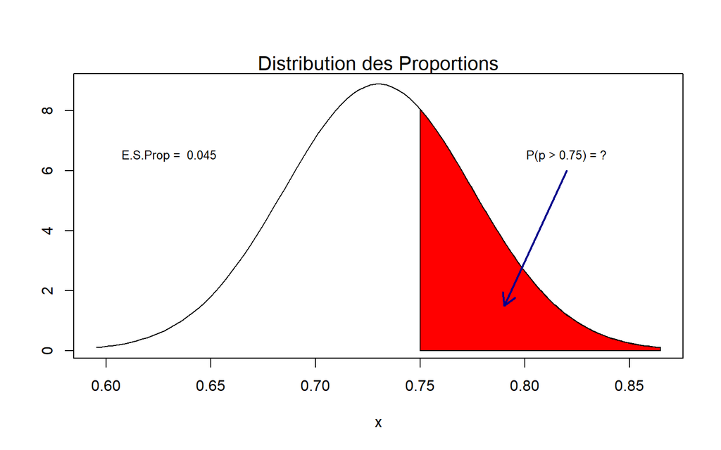

Figure 9.26: Distribution des proportions et calculs de probabilités

En unité d’erreur-standard des proportions, la distance séparant *p*=0.75 de $\pi=0.72$ est égale à:

$$Z=\frac{0.75-0.72}{0.045}=0.667$$

Sous la distribution normale standardisée, l’aire à droite de $p=0.75$ (ou de manière équivalente, $Z=0.667$) occupe une proportion de la distribution égale à:

```r
pr <- pnorm(0.667, lower.tail=FALSE)
cat("P(Z > 0.667) = ", pr)
```

```
#> P(Z > 0.667) =  0.2523861
```

De manière alternative, on peut utiliser les données non transformées pour obtenir un résultat identique:

```r
pr  <- pnorm(0.75,
             mean=0.72,
             sd=0.0449,
             lower.tail=FALSE)
cat("P(p > 0.75) = ",pr)
```

```
#> P(p > 0.75) =  0.2520185
```

Pour fins de comparaisons, une approche empirique au calcul de cette probabilité donnerait les résultats suivants:

```r
nrep <- 10000
pEch <- replicate(nrep,
                  mean(sample(0:1,
                              100,
                              replace=TRUE,
                              prob=c(0.28, 0.72))))
xbp <-  mean(pEch)
sdp <- sd(pEch)
skp <- moments::skewness(pEch)
kup <- moments::kurtosis(pEch)
```

$$\mu_p=0.72 \qquad \sigma_p=0.045 \qquad Sk_p=-0.065 \qquad Ku_p=3.01$$
$$P(p > 0.75) = 0.22$$

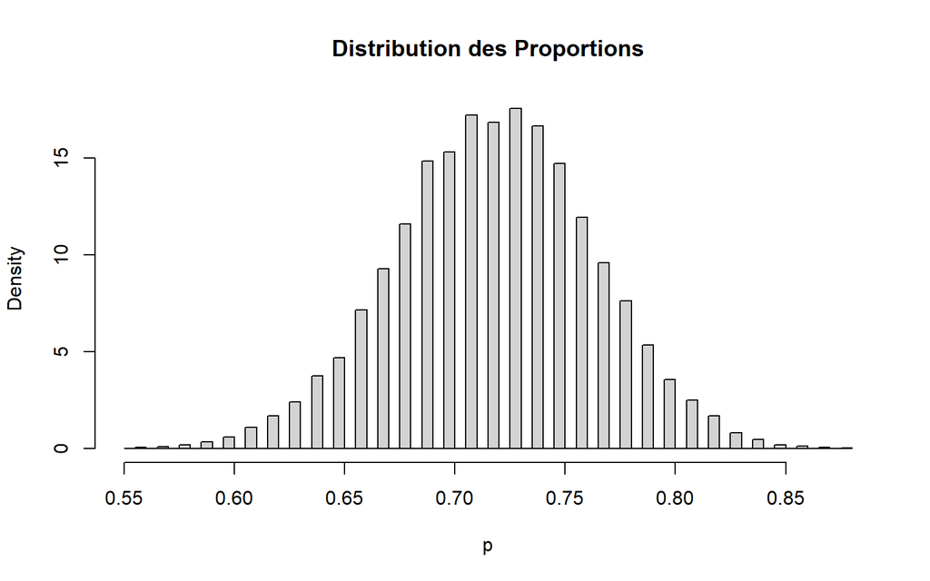

Figure 9.27: Distribution des proportions

Ces résultats sont en accord avec ceux obtenus de manière analytique. La moyenne de la distribution est essentiellement égale à la proportion au niveau de la population, $\pi$, et l’erreur standard des proportions ne se démarque que très peu de l’erreur-standard théorique. De plus, on confirme au moins visuellement ( Figure 9.27) que la distribution gaussienne est un modèle adéquat pour cette situation, ce qui est renforcé par un indice de symétrie se rapprochant de 0, et un indice de voussure égal à 3.0, marques d’une distribution normale. Et finalement, la probabilité que la proportion obtenue d’un échantillon soit supérieure à 0.75 est du même ordre de grandeur que celle obtenue de manière théorique.

**MINI-QUIZ 4**

**Vrai ou Faux**:

- Dans la distribution d’échantillonnage des proportions, la moyenne de la distribution est égale à la proportion de succès dans la population.
- La distribution d’échantillonnage des proportions est toujours normalement distribuée, quelle que soit la taille de l’échantillon.
- La variance de la distribution d’échantillonnage des proportions diminue à mesure que la taille de l’échantillon augmente.
- Plus la taille de l’échantillon est grande, plus la distribution d’échantillonnage des proportions devient large.
- Plus la taille de l’échantillon est grande, plus la distribution d’échantillonnage des proportions est asymétrique
- L’erreur standard de la distribution d’échantillonnage des proportions diminue à mesure que la taille de l’échantillon augmente.

**Choix multiples**:

- Dans la distribution d’échantillonnage des proportions, la moyenne de la distribution est :

  Toujours égale à la proportion de succès dans la population.Toujours égale à 0.5.Dépend de la taille de l'échantillon.Ne peut pas être déterminée.
- La variance de la distribution d’échantillonnage des proportions :

  La taille de l'échantillon.La taille de l'échantillon et la proportion de succès dans la population.La proportion de succès dans la population.La moyenne de la distribution.
- La distribution d’échantillonnage des proportions devient asymétrique positive lorsque :

  La taille de l'échantillon est grande.La taille de l'échantillon est petite.La proportion de succès dans la population est faible.La proportion de succès dans la population est élevée.

## 9.6 Distribution d’échantillonnage des quartiles

On l’a dit, il est possible d’établir une distribution d’échantillonnage pour toute quantité que l’on peut obtenir d’un échantillon. Certaines statistiques sont fréquemment concernées (moyenne, variance, proportion) et pour celles-là, on peut opérer de manière empirique, ou de manière théorique si les postulats qui les concernent sont respectés. D’autres statistiques sont peut-être moins fréquemment étudiées, mais non moins intéressantes dans divers contextes de recherche. Par contre, il est possible qu’aucune formulation théorique ne puisse nous aider à spécifier les paramètres de leur distribution d’échantillonnage. Un percentile fait partie de ce groupe.

### 9.6.1 Le troisième Quartile: Q3

Par exemple, supposons que dans une recherche particulière, la statistique d’intérêt soit le troisième quartile (ou Q3). À quoi pourrait ressembler sa distribution d’échantillonnage? En tirant un grand nombre d’échantillons d’une certaine taille et en calculant pour chacun d’eux la valeur de ce quartile, à quelle forme devrait-on s’attendre pour la distribution d’échantillonnage obtenue de cette manière? Quelle serait sa moyenne? Quelle serait son erreur-standard?

Dans un tel cas, la simulation est la seule approche possible, et elle s’applique de la même manière que pour les statistiques étudiées jusqu’à maintenant.

#### 9.6.1.1 Population distribuée normalement:

Supposons une population normalement distribuée avec une moyenne $\mu=50$ et un écart-type $\sigma=8$. Le code R suivant génère une telle population ($N=1,000,000$), et calcule les indices de position, incluant les quartiles:

```r
set.seed(150752)
xnorm <- rnorm(1000000,50,8)
posidx <- summary(xnorm)
posidx
```

```
#>    Min. 1st Qu.  Median    Mean 3rd Qu.    Max.
#>   10.24   44.63   50.02   50.02   55.40   88.65
```

Le troisième Quartile (Q3) est égal à 55.403. Établissons maintenant la distribution d’échantillonnage de cette quantité et tirant un grand nombre d’échantillons de taille *n*=50, et en calculant pour chacun d’eux la valeur de Q3. Finalement, on obtient la moyenne et l’écart-type de la distribution d’échantillonnage des Q3s. La Figure 9.28 représente la distribution résultant de ces opérations.

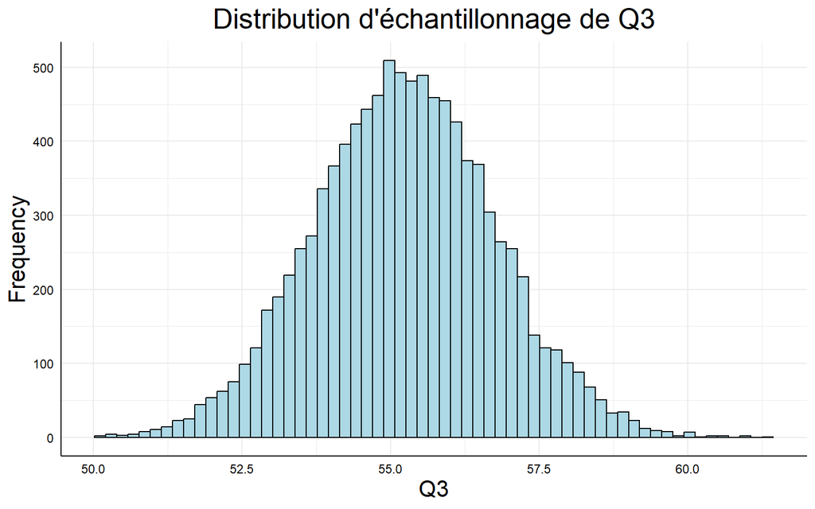

Figure 9.28: Distribution d’échantillonnage de Q3 (n=50)

Les caractéristiques de la distribution d’échantillonnage de Q3 sont les suivantes:

$$\mu_{Q3}=55.236 \qquad \sigma_{Q3}=1.52$$
$$Sk_{Q3}=0.036 \qquad Ku_{Q3}=3.017$$

Cette distribution semble gaussienne, du moins en apparence. L’indice de symétrie $Sk= 0.036$ est pratiquement nul, et l’indice de voussure $Ku = 3.017$ est approximativement égal à 3.0. Ces deux indices confirment donc la nature gaussienne de la distribution d’échantillonnage de Q3, au moins lorsque la distribution de la population est normale.

La moyenne de la distribution, $\mu_{Q3}= 55.236\approx 55.403$, la valeur de $Q3$ au niveau de la population. On pouvait s’y attendre à ce résultat. Finalement, l’erreur-standard de Q3, $\sigma_{Q_3}= 1.52$, représente la dispersion de la distribution d’échantillonnage. Sous réserve du respect des postulats habituels, cette donnée permettra d’obtenir des distances standardisées, sous cette distribution.

##### 9.6.1.1.1 Calcul de probabilités sous la distribution de Q3

Connaissant la nature de la distribution (gaussienne) et son erreur-standard ($\sigma_{Q3}=1.52$), quelle est la probabilité, en tirant un échantillon de 50 observations, que la valeur de Q3 soit supérieure à 56?

Empiriquement, la réponse à cette question s’obtient en obtenant le nombre de valeurs de Q3 dépassant 56:

```r
pr <- mean(DistQ3 > 56)
```

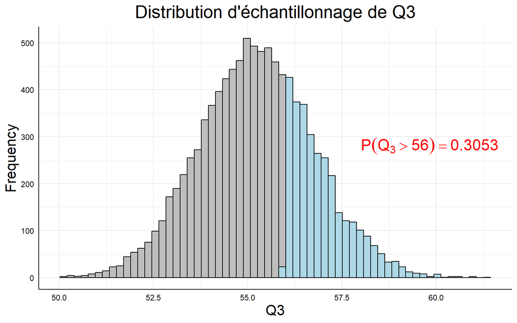

De manière théorique, étant donné la nature Gaussienne de la distribution d’échantillonnage de Q3, et connaissant sa moyenne ($\mu_{Q3}=55.236$) et son erreur-standard ($\sigma_{Q3}=1.52$), il suffira de déterminer l’aire sous la distribution normale au-delà de 56. Q3 = 56 correspond à :

```r
z <- (56 - moyQ3) / seQ3
```

En utilisant la fonction **pnorm()**, on trouve:

```r
pr <- pnorm(56, moyQ3, seQ3, lower.tail=FALSE)
```

[figure not shown]

Les deux estimations obtenues sont presque identiques, ce qui nous conforte quant à la validité de la procédure.

On peut donc conclure que la distribution d’échantillonnage de Q3 est gaussienne, avec une moyenne égale, à la limite, au troisième quartile de la population et une erreur-standard valide, conditionnel à une population normalement distribuée et un échantillon de grande taille. Cependant, aucune formulation n’est disponible pour calculer l’erreur-standard de Q3: on doit obtenir cette quantité de manière empirique.

#### 9.6.1.2 Population distribuée de manière uniforme

Vérifions si la normalité de la distribution d’échantillonnage de Q3 est maintenue lorsque la population d’où sont tirés les échantillons est distribuée de manière uniforme. Le code R suivant génère une population de 1,000,000 observations, comme dans l’expérience précédente. Les données sont comprises entre 0 et 10. Les quartiles sont obtenus au niveau de la population:

```r
set.seed(150752)
xunif <- runif(1000000, 0, 10)
posidx <- summary(xunif)
posidx
```

```
#>      Min.   1st Qu.    Median      Mean   3rd Qu.      Max.
#>  0.000005  2.512229  5.013331  5.008645  7.504865  9.999996
```

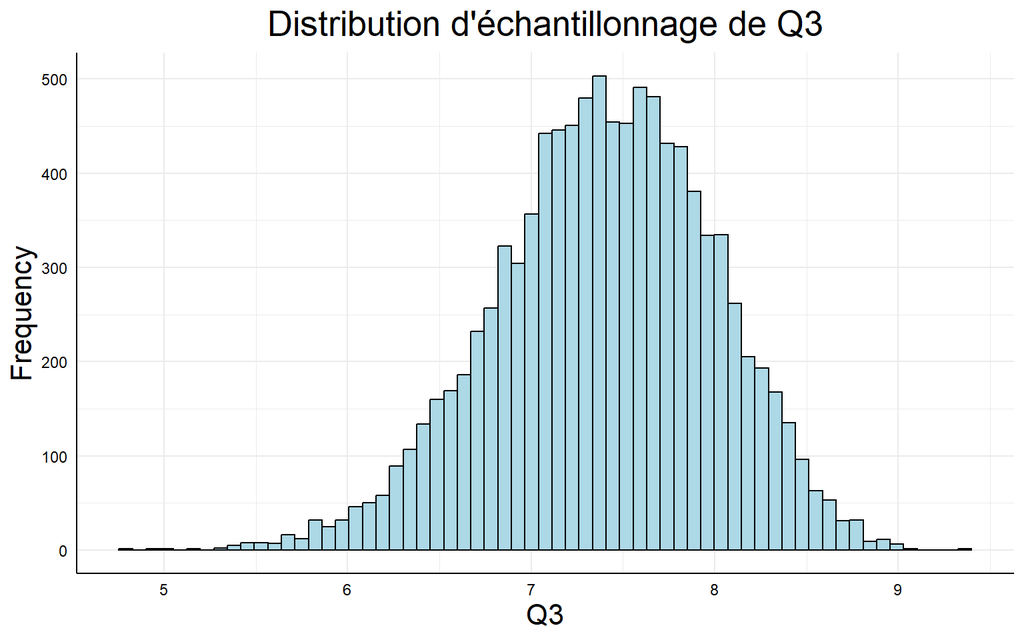

Figure 9.29: Distribution d’échantillonnage de Q3, pour des échantillons de taille n=50 observations tirées d’une distribution uniforme

```r
set.seed(150752)
nrep <- 10000
DistQ3 <- replicate(nrep, quantile(sample(xunif, 50), 0.75))
DistHist(DistQ3,
         stat = "Q3",
         title = "Distribution d'échantillonnage de Q3",
         col = "lightblue")
moyQ3 <- mean(DistQ3)
seQ3 <- sd(DistQ3)
skQ3 <- moments::skewness(DistQ3)
kuQ3 <- moments::kurtosis(DistQ3)
```

Les caractéristiques de la distribution d’échantillonnage de Q3 sont les suivantes:

$$\mu_{Q3}=7.398 \qquad \sigma_{Q3}=0.597$$
$$Sk_{Q3}=-0.268 \qquad Ku_{Q3}=3.01$$

La moyenne de cette distribution est relativement près de la valeur de Q3 au niveau de la population. La voussure est pratiquement égale à 3.0, mais on note une légère asymétrie négative ($Sk=-0.268$). Si on utilisait la distribution normale comme modèle pour le calcul de probabilités, nous obtiendrions des valeurs erronées. Cette observation implique la possibilité qu’une distribution gaussienne au niveau de la population d’où sont tirés les échantillons puisse être nécessaire pour permettre l’examen de la distribution des Q3s.

Pour illustrer, quelle est la probabilité que le troisième quartile d’un échantillon de 50 observations tiré d’une distribution uniforme {0,…,10} soit supérieur à 8?

```
- par simulation:
```

```r
pr <- mean(DistQ3 > 8)
```

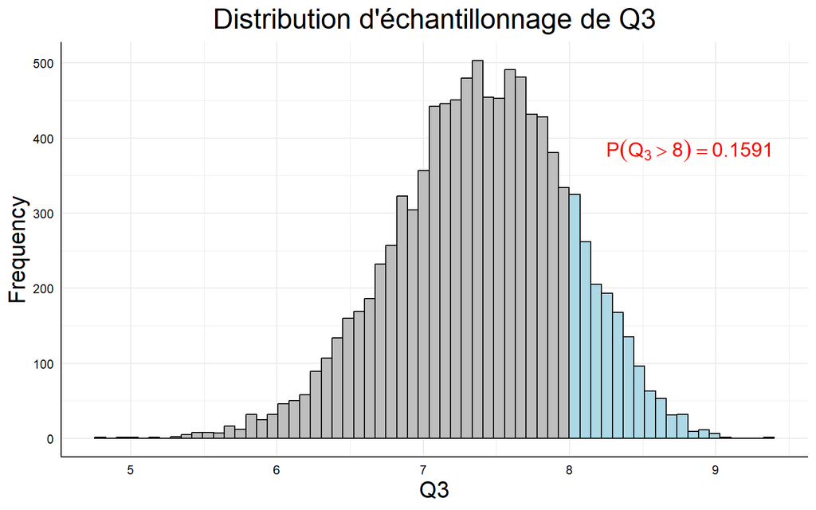

```
- En utilisant la distribution normale:
```

```r
z <- (8 - moyQ3) / seQ3
pr <- pnorm(z, lower.tail=FALSE)
```

$$z_8=\frac{8-7.398}{0.597}=1.009$$

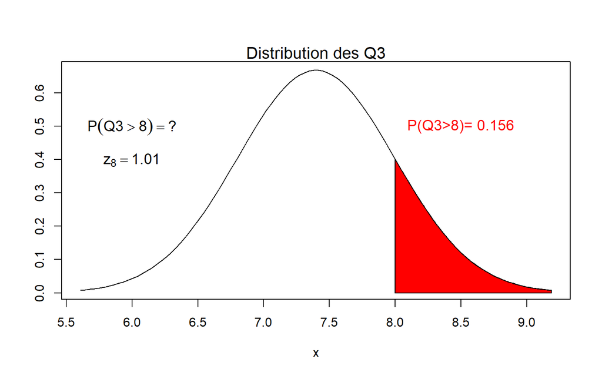

La différence entre les deux résultats est relativement faible, mais rappelons que le degré d’asymétrie n’est pas très élevé non plus. On pourrait aisément croire que la différence serait plus prononcée pour l’examen de percentiles plus extrêmes.

### 9.6.2 Le premier Quartile

Que se passerait-il dans le cas du premier quartile (Q1)? Il est très probable que les observations faites sur la distribution d’échantillonnage des Q3s rejoignent celles que nous nous apprêtons de faire.

#### 9.6.2.1 Population distribuée normalement

Répétons l’expérience, en s’intéressant à Q1, cette fois. Pour une population normalement distribuée, on obtient la distribution d’échantillonnage représentée à la Figure 9.30. Le code R suivant produit une simulation impliquant la formation de 10,000 échantillons tirés la la population utilisée à la section précédente (Section 9.6.1.1). Pour chacun de ces échantillons, on calcule la valeur du premier quartile (Q1):

```r
set.seed(150752)
nrep <- 10000
DistQ1 <- replicate(nrep,
                    quantile(sample(xnorm, 50), 0.25))
```

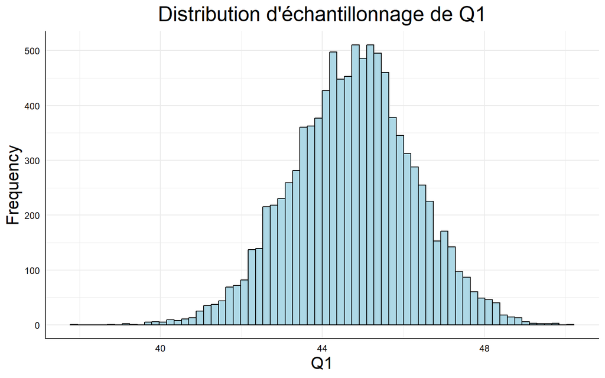

Figure 9.30: Distribution d’échantillonnage de Q1 pour des échantillons de n=50 observations tirées d’une distribution Gaussienne

Les caractéristiques de la distribution d’échantillonnage de Q1 sont les suivantes:

$$\mu_{Q1}=44.749 \qquad \sigma_{Q1}=1.506$$
$$Sk_{Q1}=-0.087 \qquad Ku_{Q1}=3.08$$

Dans le cas de Q1, on obtient une distribution d’échantillonnage raisonnablement normale: l’indice de symétrie est très près de 0, et l’indice de voussure est égal à 3.0. On peut donc croire que la distribution normale peut être utile pour le calcul de probabilités concernant Q1, comme c’était le cas pour Q3.

##### 9.6.2.1.1 Calcul de probabilités sous la distribution de Q1

Connaissant la nature de la distribution (gaussienne) et son erreur-standard ($\sigma_{Q1}=1.506$), quelle est la probabilité, en tirant un échantillon de 50 observations, que la valeur de Q1 soit supérieure à 46?

- **Par simulation**:

Empiriquement, la réponse à cette question s’obtient en obtenant le nombre de valeurs de Q1 dépassant 46. Utilisant la distribution d’échantillonnage de Q1 illustrée à la Figure 9.30, on s’intéresse à la zone rouge :

```r
pr <- mean(DistQ1 > 46)
```

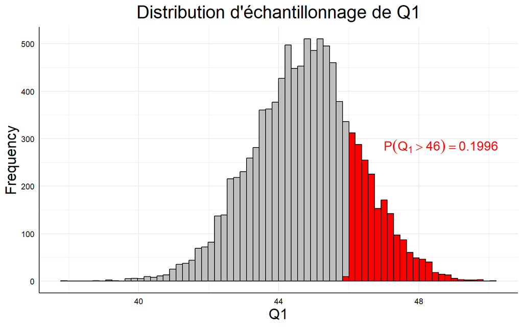

Figure 9.31

$$P(Q1>46)=0.1996$$

- **En utilisant une approche théorique à l’aide de la distribution normale**:

```r
z <- (46-moyQ1) / seQ1
pr <- pnorm(z, lower.tail = FALSE)
```

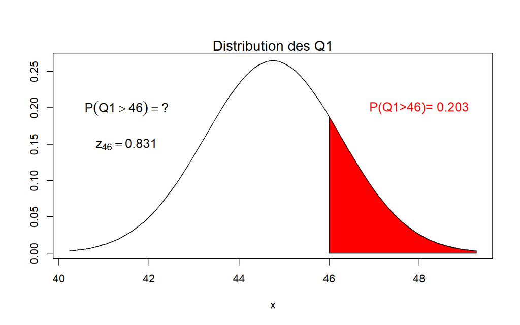

Cette probabilité est presqu’identique à celle obtenue de manière empirique et indiquée dans la Figure 9.31.

On peut donc avancer que la distribution normale est un modèle adéquat pour le calcul de probabilités impliquant le premier quartile pour autant que la population d’où sont tirés les échantillons soit gaussienne. Cependant, comme c’est le cas pour l’erreur-standard de Q3, aucune formulation n’est disponible pour calculer l’erreur-standard de Q1: on doit obtenir cette quantité de manière empirique.

#### 9.6.2.2 Population distribuée de manière uniforme

Lorsque la distribution de la population est uniforme, on obtient la distribution d’échantillonnage de Q1 affichée dans la Figure 9.32. Les échantillons, de taille $n=50$, sont formés à l’aide du code R suivant:

```r
set.seed(150752)
nrep <- 10000
DistQ1 <- replicate(nrep,
                    quantile(sample(xunif, 50), 0.25))
```

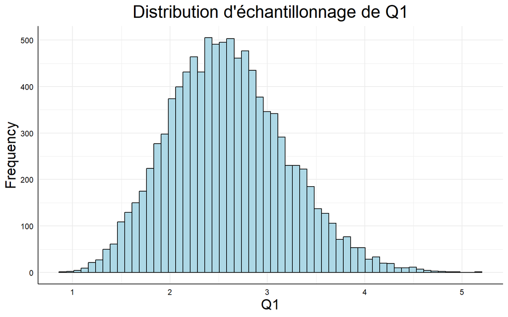

Figure 9.32: Distribution d’échantillonnage de Q1 pour des échantillons de n=50 observations tirées d’une distribution uniforme

Les caractéristiques de la distribution d’échantillonnage de Q1 sont les suivantes:

$$\mu_{Q1}=2.595 \qquad \sigma_{Q1}=0.601$$
$$Sk_{Q1}=0.323 \qquad Ku_{Q1}=3.019$$
On note, comme c’était le cas pour la distribution d’échantillonnage de Q3, une distribution légèrement asymétrique. Cependant, cette asymétrie est positive, contrairement à la distribution de Q3, qui était négative. Cette asymétrie serait davantage prononcée si on impliquait des percentiles plus extrêmes. De ce fait, la distribution normale pourrait ne pas être appropriée pour le calcul de probabilités. L’approche empirique a l’avantage de ne pas devoir se soumettre à ce postulat.

Le postulat de la normalité de la population doit donc être respecté si l’objectif d’un exercice est d’obtenir des probabilités en utilisant une approche théorique et la distribution normale comme modèle. L’approche empirique n’es pas contrainte au respect de ce postulat.

### 9.6.3 Le second Quartile (médiane)

Le deuxième quartile (Q2) correspond à la médiane, indiquant le point central de la séquence ordonnée des observations. C’est donc le point le plus éloigné des valeurs extrêmes de la distribution. On devrait donc s’attendre à ce que la distribution d’échantillonnage de la médiane soit symétrique et gaussienne. L’expérience suivante permettra de vérifier cela.

#### 9.6.3.1 Population distribuée normalement

Reprenons la distribution normale utilisée pour Q1 et Q3 (Section 9.6.1.1), tirons un grand nombre d’échantillons de taille 50 et pour chacun d’eux, calculons la médiane. Le code R suivant exécute cette tâche. Finalement, examinons les caractéristiques de la distribution des médianes observées, illustrée à la Figure 9.33.

```r
set.seed(150752)
nrep <- 10000
DistQ2 <- replicate(nrep,
                    median(sample(xnorm, 50)))
moyQ2 <- mean(DistQ2)
seQ2 <- sd(DistQ2)
skQ2 <- moments::skewness(DistQ2)
kuQ2 <- moments::kurtosis(DistQ2)
```

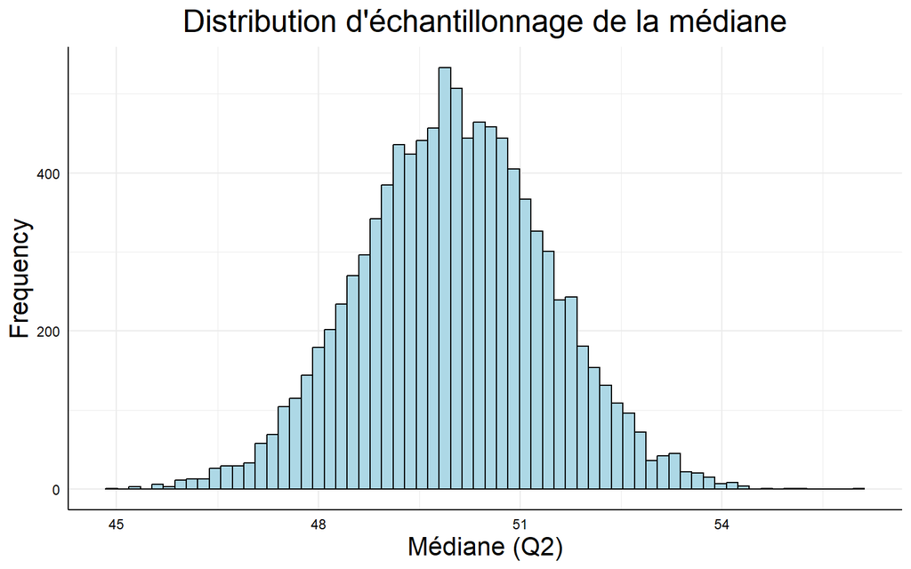

Figure 9.33: Distribution d’échantillonnage de la médiane pour des échantillons de n=50 observations tirées d’une population normalement distribuée

$$\mu_{Q2}=50.02 \qquad \sigma_{Q2}=1.397$$
$$Sk_{Q2}=-0.006 \qquad Ku_{Q2}=3.007$$

Dans un premier temps, une distribution gaussienne est apparente, ce qui est confirmé par un indice de symétrie essentiellement nul, et un indice de voussure approximativement égal à 3.0. La moyenne de la distribution d’échantillonnage, égale à 50.02 est approximativement égale à la médiane de la population (50.017), un résultat auquel on pouvait s’attendre. L’erreur-standard, $\sigma_{Med}=$ 1.3967904 représente la dispersion des médianes échantillonnales. Notons que pour des échantillons de grande taille tirés d’une population distribuée normalement, l’erreur-standard des médianes est approximativement égale à $\sigma_{Med}\approx 1.253\sigma_{\bar X}$. On peut vérifier ce fait:

```r
se.moy <- sd(xnorm)/sqrt(50) # erreur-standard des moyennes
se.med <- 1.253*se.moy       # erreur-standard des médianes (théorique)
```

$$\sigma_{\bar{X}}=\frac{\sigma_X}{\sqrt{n}}=\frac{8.001}{7.071}=1.132$$
$$\sigma_{Md_{X}}=1.253 \; \sigma_{\bar{X}}=1.253(1.132)=1.418$$

On trouve donc une approximation raisonnable: obtenue de manière empirique ou théorique, les deux quantités ($\sigma_{Q2}=1.3968$, vs $\sigma_{Md_x}=1.4179$) sont du même ordre de grandeur.

Puisque la distribution d’échantillonnage est normale, on peut obtenir les probabilités en utilisant la distribution gaussienne. Par exemple, quelle est la probabilité, en tirant un échantillon de 50 observations, que la médiane de cet échantillon soit inférieure à 48?

- **Par simulation**:

```r
pr <- mean(DistQ2 < 48)
```

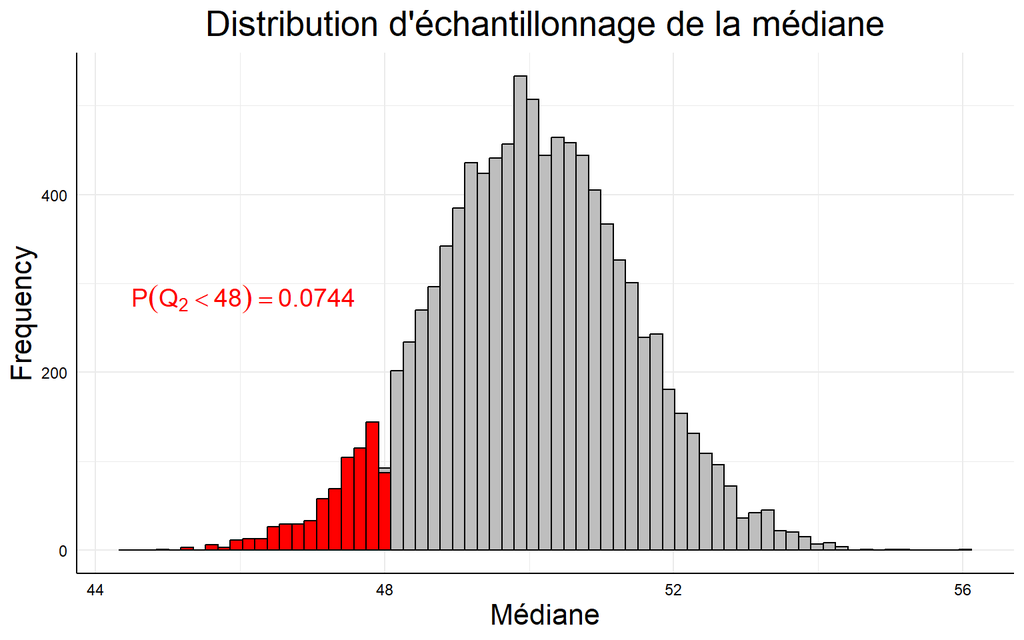

Figure 9.34

La probabilité recherchée est $P(Q2<48)=0.0744$.

- **Approche analytique, à l’aide de la distribution normale** :

La médiane de la population est: 50.017, et l’erreur-standard, $s_{Md}=1.253 \sigma_{\bar{X}}$, est 1.418. On trouve donc:

```r
Z <- (48 - median(xnorm)) / se.med
pr <- pnorm(Z, lower.tail = TRUE)
```

$$z_{48}=\frac{48-50.02}{1.418} = -1.423$$

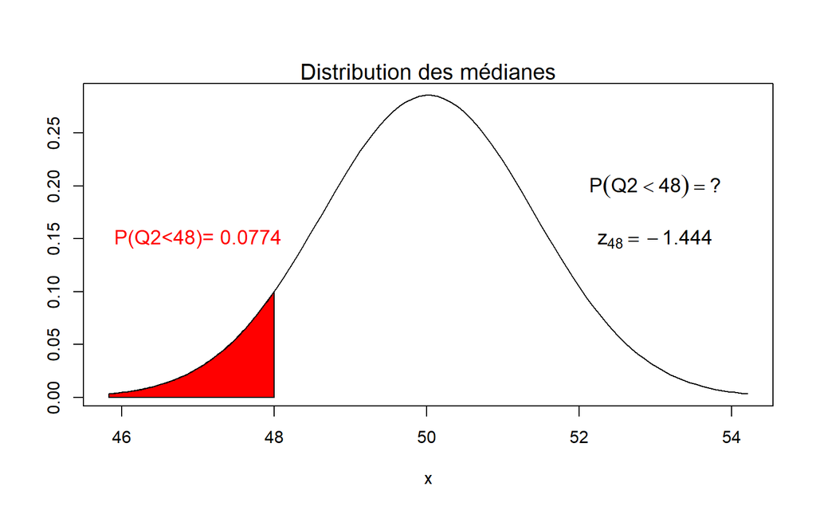

On trouve:

$$P(Md<48)=P(z<-1.423)=0.0774$$

On peut donc conclure que le modèle Gaussien est approprié pour la distribution d’échantillonnage des médianes, au moins pour des échantillons de grande taille.

#### 9.6.3.2 Population distribuée de manière uniforme

On a pu constater que la distribution d’échantillonnage de Q1 ou de Q3 dévie de la normalité, lorsque la population d’où sont tirés les échantillons n’est pas normale. Cette déviation par rapport à la normalité s’accentue pour les percentiles plus extrêmes. De ce fait, le modèle gaussien est inapplicable pour le calcul de probabilités relatives aux percentiles se rapprochant des extrémités de la distribution. En ce qui concerne le second quartile, la médiane, les résultats pourraient être différents du fait que cette quantité occupe la position centrale de la distribution. Il convient donc d’examiner ce cas.

Le code suivant génère la distribution d’échantillonnage de la médiane, représentée à la Figure 9.35, à partir d’échantillons de 50 observations tirés d’une population distribuée de manière uniforme:

```r
set.seed(150752)
nrep <- 10000
DistQ2 <- replicate(nrep, median(sample(xunif, 50)))
moyQ2 <- mean(DistQ2)
seQ2 <- sd(DistQ2)
skQ2 <- moments::skewness(DistQ2)
kuQ2 <- moments::kurtosis(DistQ2)
```

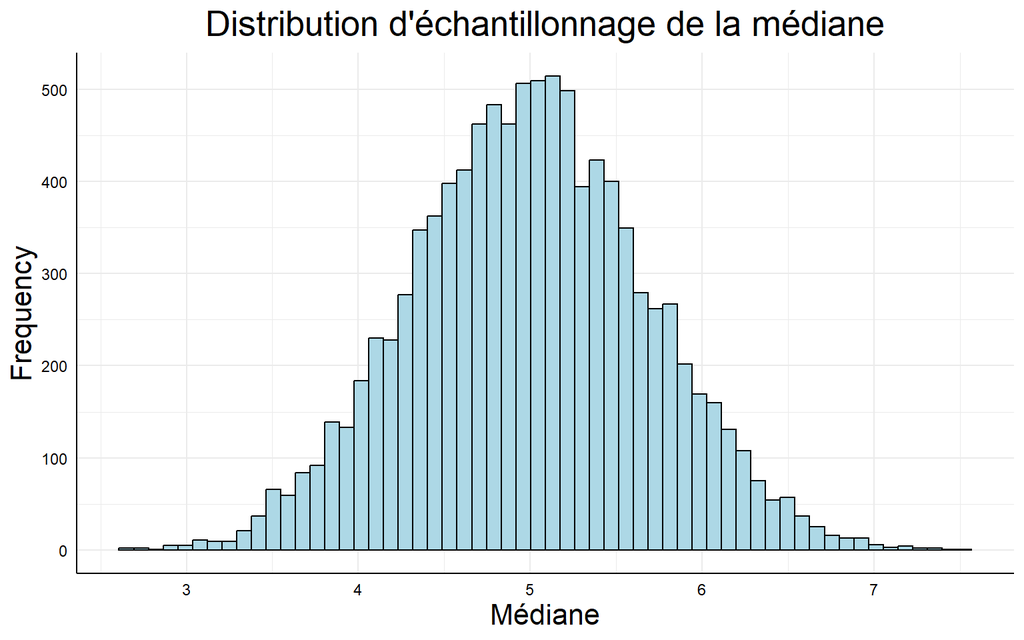

Figure 9.35: Distribution d’échantillonnage de la médiane pour des échantillons de n=50 observations tirées d’une population uniforme

```r
DistHist(DistQ2,
         lb = 48,
         stat = "Médiane",
         title = "Distribution d'échantillonnage de la médiane",
         col = "lightblue")
```

Les caractéristiques de la distribution d’échantillonnage de la médiane sont les suivantes:

$$\mu_{Q2}=5 \qquad \sigma_{Q2}=0.686$$
$$Sk_{Q2}=0.042 \qquad Ku_{Q2}=2.93$$

En apparence au moins, la distribution d’échantillonnage des médianes est gaussienne, ce qui se confirme par un indice de symétrie pratiquement nul, et un indice de voussure se rapprochant de $Ku=3.0$. Mais peut-on se fier à la relation mise en évidence dans le paragraphe précédent entre l’erreur-standard des moyennes et l’erreur-standard des médianes?

```r
seMoy <- sd(xunif)/sqrt(50)
seQ2b <- 1.253*seMoy
```

$$s_{Md}=0.511 \qquad [théorique]$$
$$s_{Md}=0.686 \qquad [empirique]$$
L’erreur-standard théorique correspond à 1.253 fois l’erreur-standard des moyennes; l’erreur-standard empirique correspond à l’écart-type de la distribution des médianes. Ces deux quantités, qui s’équivalaient lorsque la distribution de la population était gaussienne, sont sensiblement différentes dans le cas d’une population distribuée de manière uniforme. Cette expérience démontre clairement que lorsque la population n’est pas gaussienne, l’estimation théorique de l’erreur-standard des médianes est erronée. On ne saurait recommander le calcul de probabilités en utilisant une approche théorique si on ne peut pas croire à la normalité de la distribution de la population.

### 9.6.4 95ième percentile

En examinant les distributions d’échantillonnage de Q1 et de Q3, on a pu noter une certaine asymétrie de ces distributions. On a également noté que le degré d’asymétrie pouvait augmenter pour des percentiles plus extrêmes. Pour illustrer ce fait, considérons la distribution d’échantillonnage de $P_{}95$, illustrée à la Figure 9.36. Comme pour les autres fractiles, 10,000 échantillons de $n=50$ observations sont tirés d’une distribution uniforme. On calcule $P_{95}$ pour chacun de ces échantillons, pour ensuite en former la distribution. Le code R suivant effectue ce travail:

```r
set.seed(150752)
nrep <- 10000
DistP95 <- replicate(nrep,
                     quantile(sample(xunif, 50), 0.95))
moyP95 <- mean(DistP95)
seP95 <- sd(DistP95)
skP95 <- moments::skewness(DistP95)
kuP95 <- moments::kurtosis(DistP95)
```

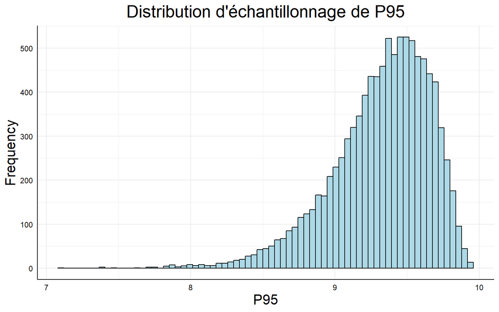

Figure 9.36: Distribution d’échantillonnage du 95e percentile

```r
DistHist(DistP95,
         stat = "P95",
         title = "Distribution d'échantillonnage de P95",
         col = "lightblue")
```

Les caractéristiques de la distribution d’échantillonnage du 95ième percentile ($P_{95}$ sont les suivantes:

$$\mu_{P_{95}}=9.321 \qquad \sigma_{P_{95}}=0.341$$
$$Sk_{P_{95}}=-0.998 \qquad Ku_{P_{95}}=4.497$$

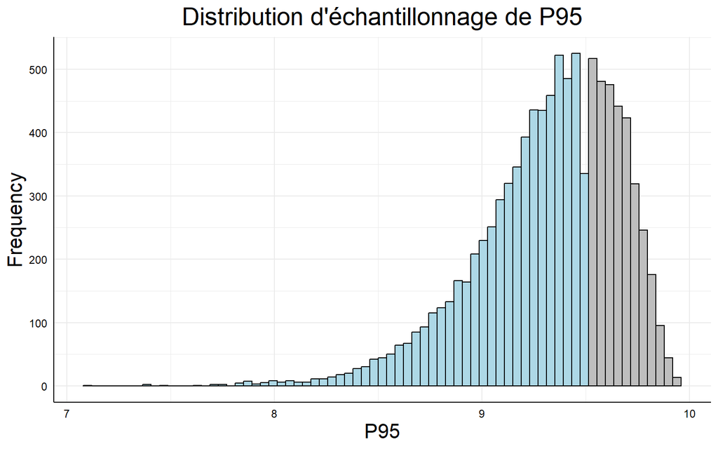

Figure 9.37: Calcul de probabilité à partir de la Distribution d’échantillonnage de P95, pour des échantillons de n=50

```r
DistHist(DistP95,
         lb = 9.5,
         stat = "P95",
         title = "Distribution d'échantillonnage de P95",
         col = "lightblue")
```

```r
z <- (9.5 - moyP95) / seP95
pr <- pnorm(z, lower.tail=FALSE)
```

En utilisant l’approche empirique, on obtient:

```r
pr <- mean(DistP95 > 9.5)
```

Rappelons que l’asymétrie observée dans le cas des fractiles situés dans les extrémités de leur distribution est, comme c’est le cas pour les proportions (voir section Section 9.5.1), liée au fait que cette distribution est limitée par la valeur maximale de la distribution de la population.

## 9.7 Mise en oeuvre

```r
if(!exists("HaitiPop")){load("./data/HaitiPop_Env.RData")}

# Départements du Nord (6, 7 et 8)
subpop = subset(HaitiPop,
                ((AGE>=15)&(DEPARTEMENT %in% c("6","7","8"))),
                CRIMIDX)
# Caractéristiques de la population
pop.n <- length(subpop$CRIMIDX)
pop.moy <- mean(subpop$CRIMIDX)
pop.var <- var(subpop$CRIMIDX)
pop.sd <- sd(subpop$CRIMIDX)
pop.sk <- moments::skewness(subpop$CRIMIDX)
pop.ku <- moments::kurtosis(subpop$CRIMIDX)

tbl <- data.frame(
  "Paramètres" = c("Taille", "Moyenne", "Variance", "Écart-type", "Indice de symétrie", "Indice de voussure" ),
  "Valeur" = round(c(pop.n, pop.moy, pop.var, pop.sd, pop.sk, pop.ku), 3)
)

tbl %>%
  kbl()
```

| Paramètres | Valeur |
| --- | --- |
| Taille | 3482941.000 |
| Moyenne | 125.772 |
| Variance | 587.777 |
| Écart-type | 24.244 |
| Indice de symétrie | -0.760 |
| Indice de voussure | 3.123 |

Figure 9.38: Distribution de l’indice de criminalité au niveau des départements du Nord d’Haiti

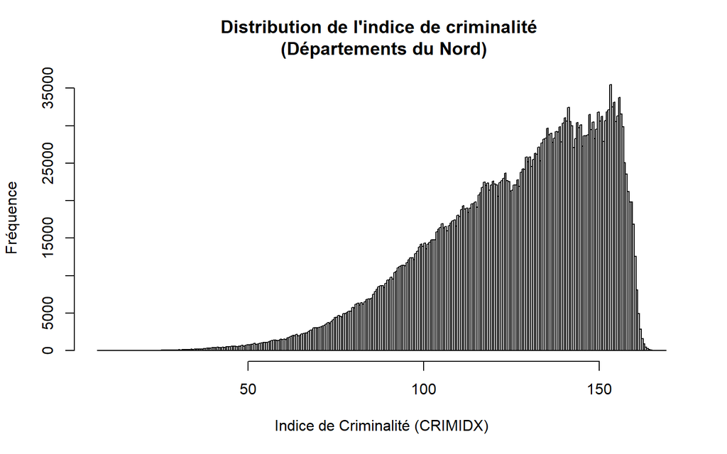

Figure 9.39: Distribution de l’indice de criminalité au niveau des départements du Nord d’Haiti

```r
hist(subpop$CRIMIDX,
     breaks="FD",
     main="Distribution de l'indice de criminalité \n (Départements du Nord)",
     xlab="Indice de Criminalité (CRIMIDX)",
     ylab="Fréquence")
```

Quelles valeurs de moyennes et de variances peut-on s’attendre d’obtenir, en tirant un grand nombre d’échantillons de taille *n* = 30 à partir d’une telle population?

À l’instar des exemples présentés dans les sections précédentes, tirons 10,000 échantillons aléatoires, et pour chacun d’eux, calculons la moyenne et la variance que l’on convertira en $\chi^2$. Au préalable, définissons une fonction permettant ces calculs:

```r
EchMoyVar <- function(x, v){
  # x = données échantillonnales
  # v = variance de la population
  # Calcul de la moyenne et transformation de la variance en chi-carré
  res <- c(mean(x),(length(x)-1)*var(x)/v)
  return(res)
}
```

Les distributions d’échantillonnage des moyennes et des variances sont reproduites dans les figures Figure 9.40 et Figure 9.41 respectivement, et leurs caractéristiques sont calculées à l’aide des fonctions appropriées.

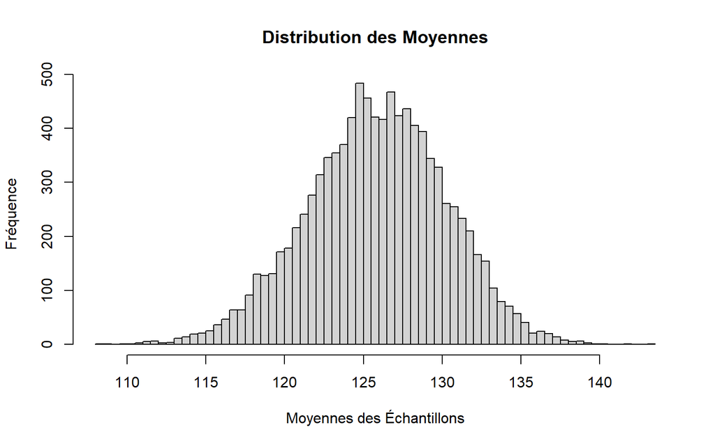

Figure 9.40: Distribution d’échantillonnage des moyennes

```r
nrep <- 10000
n <- 30
v <- var(subpop$CRIMIDX)
dat <- replicate(nrep,EchMoyVar(subpop[sample(1:nrow(subpop),n,replace=FALSE),],v))
# Distribution des Moyennes
hist(dat[1, ],
     breaks="FD",
     main="Distribution des Moyennes",
     xlab="Moyennes des Échantillons",
     ylab="Fréquence")
moy.moy <- mean(dat[1, ])
moy.sd <- sd(dat[1, ])
moy.sk <- moments::skewness(dat[1, ])
moy.ku <- moments::kurtosis(dat[1, ])
```

$$\mu_{\bar{X}} = 125.853 \qquad \sigma_{\bar{X}} = 4.413 \qquad Sk_{\bar{X}} = -0.138 \qquad Ku_{\bar{X}} = 3.01$$

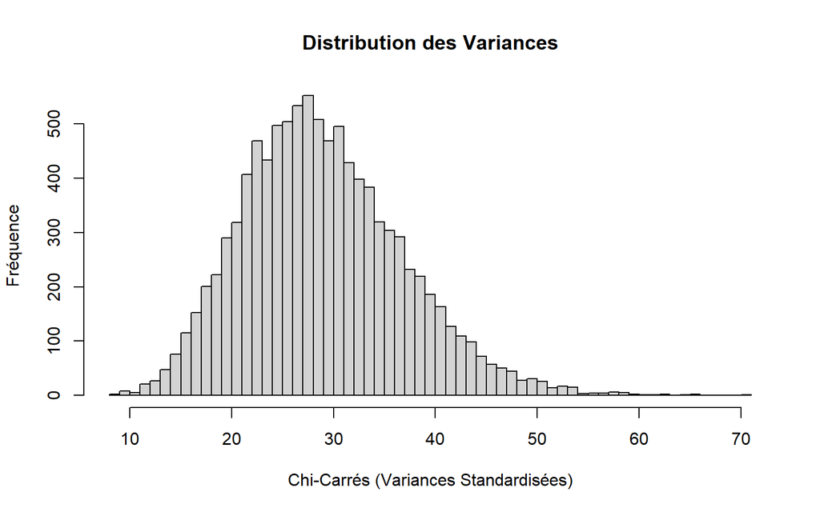

Figure 9.41: Distribution d’échantillonnage des variances

```r
hist(dat[2, ],
     breaks="FD",
     main="Distribution des Variances",
     xlab="Chi-Carrés (Variances Standardisées)",
     ylab="Fréquence")
var.moy <- mean(dat[2, ])
var.sd <- var(dat[2, ])
var.sk <- moments::skewness(dat[2, ])
var.ku <- moments::kurtosis(dat[2, ])
```

$$\mu_{s^2} = 28.958 \qquad \sigma_{s^2} = 7.843 \qquad Sk_{s^2} = 0.52 \qquad Ku_{s^2} = 3.414$$

La distribution des moyennes est au moins approximativement normale, présentant une légère asymétrie négative ($Sk=-0.138$). Sa moyenne ($\mu_{\bar X}=125.853$) est pratiquement égale à la moyenne de la population ($\mu_X=125.772$). Son erreur-standard est approximativement égal à:

$$\frac{24.244}{\sqrt{30}}=4.4263496 \approx 4.413$$

Le comportement des moyennes correspond en tout point aux résultats de simulations empiriques et du traitement théorique que nous avons présentés dans ce chapitre.

En ce qui concerne les variances, les résultats vont dans le même sens:  
- la moyenne des variances transformées ($\mu_{\chi^2}=28.958$)est égal au nombre de degrés de liberté ($dl=30-1=29$)  
- l’indice de symétrie correspond à $\sqrt{8/dl}=\sqrt{8/29}=0.525$  
- la distribution suit de très près la distribution du $\chi^2$, avec $dl=29$.

Les distributions d’échantillonnage sont donc pertinentes non seulement dans un contexte théorique, mais aussi dans des contextes appliqués, tel que nous le découvrirons chacun des chapitres suivants.

## 9.8 Conclusion

Dans ce chapitre, nous avons introduit la notion de distribution d’échantillonnage d’une statistique. Il s’agit d’une notion fondamentale qui reviendra constamment dans toutes les discussions portant sur l’inférence statistique.

Après l’étude de ce chapitre, il devrait être clair que l’on ne peut se fier aux statistiques obtenues d’un échantillon unique: elles ne sont qu’un reflet, souvent biaisé, distortionné, de la réalité d’une population. Ainsi, toute recherche scientifique traitant de variables quantitatives ne peut se limiter à la simple description des données observées sur un échantillon: les distributions d’échantillonnage illustrent sans équivoque la nature aléatoire des statistiques permettant cette description. Une statistique échantillonnale n’est qu’un exemplaire unique d’un nombre infini de valeurs possibles, et rien dans les données ne nous renseignent sur l’écart que la sépare du paramètre correspondant de la population. Il nous faut faire quelques efforts supplémentaires pour tirer profit des informations fournies par notre échantillon. Tous les chapitres suivants porteront sur ce qu’il convient de faire pour réaliser cet objectif et permettre l’énoncé de conclusions valides dans un contexte de recherche.

Tous les exemples présentés dans ce chapitre débutaient par la définition d’une population d’observations dont on connaissait les paramètres. Une population normalement, ou uniformément, distribuée était générée, et de cette population, on pouvait se permettre de tirer un très grand nombre d’échantillons d’une certaine taille. Pour chacun des échantillons tirés de la population, on calculait une ou plusieurs statistiques d’intérêt, pour finalement constituer la distribution de ces dernières: on obtenait la distribution d’échantillonnage d’une statistique donnée. Ceci nous a permis de constater la nature aléatoire des statistiques échantillonnales et leur dispersion autour du paramètre correspondant de la population. Malheureusement, de telles possibilités ne risquent pas de se réaliser en pratique: il serait difficile de répéter 100,000 fois une même expérience impliquant autant d’échantillons, pour étudier l’effet d’une substance pharmacologique sur la réduction de symptômes de la malaria, par exemple.

Dans le chapitre suivant, nous inverserons la séquence des événements de manière à revenir à un contexte de recherche plus réaliste: comment partir d’observations effectuées sur un échantillon pour apprendre quelque chose au sujet de la population d’où ce dernier a été tiré.

## 9.9 Exercice 6

Dans les exercices suivants, reprenez les procédures de simulation pour étudier les distributions d’échantillonnage de diverses autres statistiques. Les procédures sont identiques, quelle que soit la statistique.

1. Distribution d’échantillonnage de $Sk$:
- Établissez la distribution d’échantillonnage de l’indice de symétrie ($Sk$), pour des échantillons de taille 50, tirés d’une population dont la distribution est normale )$\mu = 50,~~\sigma=8$)
- Quelle est la probabilité que $Sk > 0.5$, en utilisant une approche théorique, supposant une distribution normale?
- Quelle est la probabilité que $Sk > 0.5$, en utilisant une approche empirique (le postulat de normalité n’est pas requis, dans ce cas)?
- Quelle est la probabilité que $Sk$ soit compris entre -0.5 et 0.2 pour un échantillon de 50 sujets tiré d’une population normalement distribuée?
2. Répétez l’expérience précédente, en tirant des échantillons d’une population distribuée uniformément. Quelles conclusions pouvez-vous formuler?
3. Examinez la distribution de l’indice de voussure, dans les conditions décrites dans les exercices 1 et 2.
4. **Le code R suivant génère une population de 100,000 observations ordinale (échelle de Likert en 7 points):**

```r
xord = wakefield::r_sample_ordered(n=100000,
                                   x = 1:7,
                                   prob = c(5,8,2,1,2,1,1),
                                   name = "xord")
```

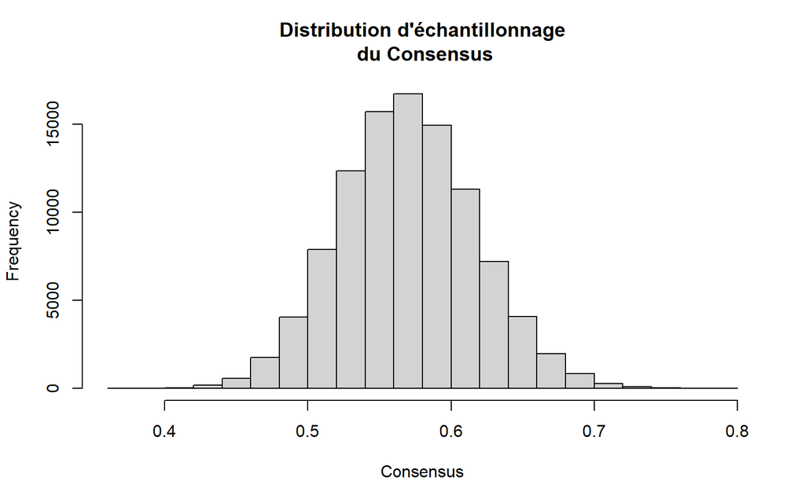

- En tirant des échantillons de 100 sujets de cette population, établissez la distribution d’échantillonnage du consensus.
  1. Quelle est la moyenne de cette distribution?
  2. Quel est l’écart-type de cette distribution?
- Quelle est la probabilité que le consensus observé pour un échantillon de 100 sujets tiré de cette population soit supérieur à 0.65?
- Quelle est la probabilité que le consensus observé pour un échantillon de 100 sujets tiré de cette population soit inférieur à 0.50?
- En tirant des échantillons de 100 sujets de cette population, à l’intérieur de quelles limites centrales retrouve-t-on 95% des indices de consensus?
5. Supposez que pour les besoins d’une recherche, vous vous intéressez à la différence entre la moyenne et la médiane obtenues pour des échantillons de 100 observations tirés d’une population normalement distribuée avec $\mu=50,~~\sigma=8$. Examinez la distribution d’échantillonnage de la différence $(\bar X - Med)$. La fonction suivante pourra vous aider:

```r
MoyMedDiff <- function(x){
  dif <- mean(x) - median(x)
  return(dif)
}
```

Prenez exemple sur les codes R utilisés dans les démonstrations précédentes et appliquez cette fonction sur chacun des échantillons tirés de la population.

- Quelle est la moyenne de la distribution d’échantillonnage des différences entre la moyenne et la médiane?
- Quelle est son erreur-standard?
- Peut-on croire à la normalité de cette distribution?

## 9.10 Appendice

Listing 9.1: DistHist()

```sql
#' Fonction DistHist(): Production d'histogrammes comportants des zones colorées
#' Arguments:
#'   x: Vecteur de données, de moyennes, ou de toute autre statistique
#'   lb: borne inférieure. Les valeurs inférieures à lb seront colorées
#'   ub: borne supérieure. Les valeurs supérieures à ub seront colorées
#'   stat: statistique considérée dans le cas d'une distribution d'échantillonnage. On peut spécifier une chaîne utilisant expression() ou TeX()
#'   title: Chaîne de caractères utilisée en tant que titre du graphique
#'   col: Couleur de la zone spécifiée par lb et ub
#'   xlim: Vecteur composé des limites de l'axe horizontal
#'
#'   Note: En sauvegardant le graphique dans une variable, on peut ajouter des éléments au graphique
#'   Exemples d'utilisation:
#'        DistHist(rnorm(1000, 100, 15), stat = TeX("$\\bar{X}$"), title = TeX("Distribution des $\\bar{X}$"))
#'
#'        data <- rnorm(100000, mean = 10, sd = 2)
#'        DistHist(data, lb = 6, ub = 13,
#'                 stat = expression(bar(X)),
#'                 title = "Distribution d'échantillonnage des Moyennes",
#'                 col = "lightblue")

DistHist <- function(x,
                     lb = NULL,
                     ub = NULL,
                     stat = expression(bar(X)),
                     title = "Distribution d\'échantillonnage des Moyennes",
                     col = "lightblue",
                     xlim = NULL){

  h <- hist(x,
            breaks = "FD",
            plot = FALSE)
  df <- data.frame(mids = h$mids, counts = h$counts)

  if (!is.null(lb) | !is.null(ub)) {
    if (!is.null(lb) & !is.null(ub)) {
      df$clr <- ifelse(df$mids < ub & df$mids > lb, "grey", col)
    } else if (!is.null(lb) & is.null(ub)) {
      df$clr <- ifelse(df$mids > lb, "grey", col)
    } else if (is.null(lb) & !is.null(ub)) {
      df$clr <- ifelse(df$mids < ub, "grey", col)
    }
  } else {
    df$clr <- col
  }

  p <- ggplot(df, aes(x = mids, y = counts, fill = clr)) +
    geom_bar(colour = "black", stat = "identity") +
    labs(title = title, x = stat, y = "Fréquence") +
    scale_fill_identity() +
    #   scale_fill_manual(values = c("grey" = "grey", "color" = col)) +
    theme_minimal() +
    theme(
      axis.title.x = element_text(size = 16),
      axis.title.y = element_text(size = 16),
      plot.title = element_text(size = 20, hjust = 0.5),
      axis.line = element_line(color = "black"),
      axis.text = element_text(color = "black")) +
    guides(fill = none)

  # Applying xlim if provided
  if (!is.null(xlim)) {
    p <- p + coord_cartesian(xlim = xlim)
  }

  return(p)
}
```

Listing 9.2: HaitiPopGen()

```sql
#'
#'Generate simulated Haiti (2019) population: 11.2 millions observations
#'
#'@return Data Frame containing the data structure:
#'        GENRE: “M” = Masculin “F” = Féminin
#'        AGE: Âge, en unité d’années
#'        EDUC: Niveau de scolarité atteint à l’âge de 25 ans - Aucun -
#'              PréScol - Fond.1 - Fond.2 - Fond.3 - Second - Univ.1 -
#'              Univ.2 - Univ.3
#'        DEPARTEMENT: Département de résidence
#'         "1"  "Artibonite"
#'         "2"  "Centre"
#'         "3"  "Grand'Anse"
#'         "4"  "Nippes"
#'         "5"  "Nord"
#'         "6"  "Nord-Est"
#'         "7"  "Nord-Ouest"
#'         "8"  "Ouest"
#'         "9"  "Sud-Est"
#'         "10" "Sud"
#'
#'        CondxVie: Indice général de condition de vie, sur une échelle de 0 à 50. Plus l’indice est élevé, plus les conditions de vie de la personne sont bonnes.
#'        CRIMIDX: Indice de propension à la criminalité et à la corruption, sur une échelle de 0 à 150. Plus l’indice est élevé, plus l’individu a des tendances criminelles.
#'        HabilCog: Indice d’habiletés cognitives, sur une échelle de 20 à 200. Plus cet indice est élevé, plus les habiletés intellectuelles et cognitives de l’individu sont grandes.
#'        PrefPres: Préférence pour un candidat donné à la présidentielle de 2022. Cinq candidats sont en liste: CandA - CandE.
#'        OpinConst: Opinion concernant à un nouveau projet de Constitution:
#'          “Tout à fait d’accord”
#'          “D’accord”
#'          “Indécis”
#'          “Pas d’accord”
#'          “Pas du tout d’accord”
#'
#'L’objet sortant est un ‘DATA.FRAME’ appelé HaitiPop.
#'@export
HaitiPopGen <- function(){
  set.seed(1234567)
  # HaitiPop: Simultation de la population Haitienne (2019)
  # Genre Féminin, effectif par groupe d'âge (données de 2019)
  Age_female=c(620842, 608143, 590011, 565536, 531966, 493101, 458841,
               410081, 309636, 245577, 218103, 187285, 149090, 118763,
               80994, 60334, 34915, 15440, 5211, 1397, 217)

  # Genre Masculin, effectif par groupe d'âge (données de 2019)
  Age_male=c(645049, 629568, 607263, 571570, 525211, 479976, 442822,
             390944, 286062, 221042, 199898, 169226, 135904, 102412,
             64604, 47325, 24681, 10151, 3085, 720, 83)
  PopTotale <- sum(Age_male)+sum(Age_female)

  # Génération des âges et du genre
  age <- c(seq(4,104,by=5))
  AGE <- vector()
  GENRE <- vector()
  for(i in 1:length(age)){
    AGE <- append(AGE,floor(runif(Age_male[i],(age[i]-4),age[i]+5)))
    AGE <- append(AGE,floor(runif(Age_female[i],(age[i]-4),age[i]+5)))
    GENRE <- append(GENRE,rep("M",Age_male[i]))
    GENRE <- append(GENRE,rep("F",Age_female[i]))
  }
  Tdt <- data.frame(AGE,GENRE)
  Tdt <- Tdt[sample(nrow(Tdt)),1:2]
  # Génération des Départements et répartition de la population
  Dept <- matrix(c(1:10,"Artibonite","Centre","Grand'Anse","Nippes",
                  "Nord","Nord-Est","Nord-Ouest","Ouest","Sud-Est",
                  "Sud"),nrow=2,byrow=TRUE)
  # cat("Identification des Départements: ","\n",t(Dept))
  # Proportion de la population par département
  PropDept <- c(0.158316776, 0.037133348, 0.024201755, 0.018140699,
               0.057563731, 0.022548639, 0.042675426, 0.24647869,
               0.051350001, 0.066312107)
  DEPARTEMENT <- sample(Dept[1,],size=PopTotale,replace=TRUE, prob=PropDept)
  # Indice de condition de vie, distribution asymétrique
  CondxVie <- rchisq(PopTotale,6)
  Tdt <- data.frame(Tdt,DEPARTEMENT,CondxVie)
  # Génération des niveaux de scolarité atteints, population adulte
  EDUC=rep("NA",PopTotale)
  NivScol <- c("Aucun","Fond.1","Fond.2","Fond.3","PréScol","Second",
              "Univ.1","Univ.2","Univ.3")
  PropNivScol <- c(0.2, 0.2, 0.18, 0.12, 0.09, 0.07, 0.06, 0.05, 0.03)
  EDUC[Tdt$AGE>25] <- sample(NivScol, sum(Tdt$AGE>25), prob=PropNivScol, replace=TRUE)

  # Génération de l'indice de criminalité

  CRIMIDX <- rep("NA",PopTotale)
  idx <- vector()
  for(i in 1:10){
    idx[i] <- sample(c(1,-1),1)*runif(1,0,30)
  }

  CRIMIDX <- 0.3*CondxVie + 3.5*(Tdt$GENRE=="M")-1.2*Tdt$AGE
  CRIMIDX <- CRIMIDX +1.5*(EDUC<"Second")+10 +rnorm(1,0,4)
  CRIMIDX <- CRIMIDX + idx[as.numeric(DEPARTEMENT)]
  CRIMIDX <- CRIMIDX + (min(CRIMIDX)<0)*abs(min(CRIMIDX))
  CRIMIDX[which(Tdt$AGE<15)] <- NA

  # Génération de l'indice d'habiletés cognitives
  HabilCog <- rnorm(PopTotale,100,15)
  idx <- vector()
  for(i in Dept){
    idx[i] <- sample(c(1,-1),1)*runif(1,0,10)
  }
  HabilCog <- HabilCog+idx[DEPARTEMENT]

  # Génération de la préférence pour un candidat présidentiel
  # et de l'Opinion concernant la proposition d'une nouvelle Constitution

  PrefPres <- rep(NA,PopTotale)
  OpinConst <- rep(NA,PopTotale)

  # Probabilités associées aux variables PresProb et OpinProb
  PresProb <- matrix(c(0.58, 0.41, 0.003, 0.004, 0.003, # Nord-Ouest, Nord et Nord-Est
                      0.41, 0.54, 0.003, 0.004, 0.043, # Artibonite et Centre
                      0.27, 0.65, 0.006, 0.01, 0.064,  # Ouest
                      0.15, 0.23, 0.38, 0.19, 0.05),   # Grand<Anse, Nippes, Sud et Sud-Est
                    nrow = 4, ncol = 5, byrow = TRUE)
  OpinProb <- matrix(c(0.5,0.3,0.1,0.05,0.05,           # Nord-Ouest, Nord et Nord-Est
                      0.2,0.4,0.1,0.1,0.2,             # Artibonite et Centre
                      0.01,0.09,0.2,0.4,0.3,           # Ouest
                      0.4,0.1,0.0,0.1,0.4),            # Grand<Anse, Nippes, Sud et Sud-Est
                    nrow = 4, ncol = 5, byrow = TRUE)
  Regions <- list(c("5","6","7"), c("1","2"), c("8"),c("3","4","9","10"))
  OptPres <- c("CandA", "CandB", "CandC", "CandD", "CandE")
  OptOpin <- c("Tout à fait d'accord","D'accord","Indécis","Pas d'accord","Pas du tout d'accord")

  for (i in 1:length(Regions)){
    select <- (Tdt$AGE>=18)&(DEPARTEMENT %in% Regions[[i]])
    PrefPres[select] = wakefield::political(n=sum(select), x = OptPres,prob = PresProb[i,], name = "PrefPres")
    OpinC <- wakefield::r_sample_ordered(n=sum(select),x = OptOpin,prob = OpinProb[i,])
    OpinConst[select] <- OpinC
  }

  # DATA.FRAME de sortie
  HaitiPop <- data.frame(Tdt,EDUC,CRIMIDX,HabilCog,PrefPres,OpinConst)
  return(HaitiPop)
}
```